# Executive Summary Navigating Educational Trajectories: Predictive Modeling of Student Educational Outcomes

Final Project  
Data Science 2 with R (STAT 301-2)

Author

Lily Ng

Published

March 13, 2024

**Github Repo Link**

[Final Project 2 GitHub Repo](https://github.com/stat301-2-2024-winter/final-project-2-lilyng3.git)

## Data Overview and Methods

The target variable I am predicting is the educational outcome, whether a student dropped out or graduated. There is no missingness in the whole dataset, including my target variable. In Figure 1, we can see that among all the observations that include the educational outcome of Dropout or Graduate, there is a difference of 788 observations between them, which is a bit of an imbalance, but not enough to transform the data.

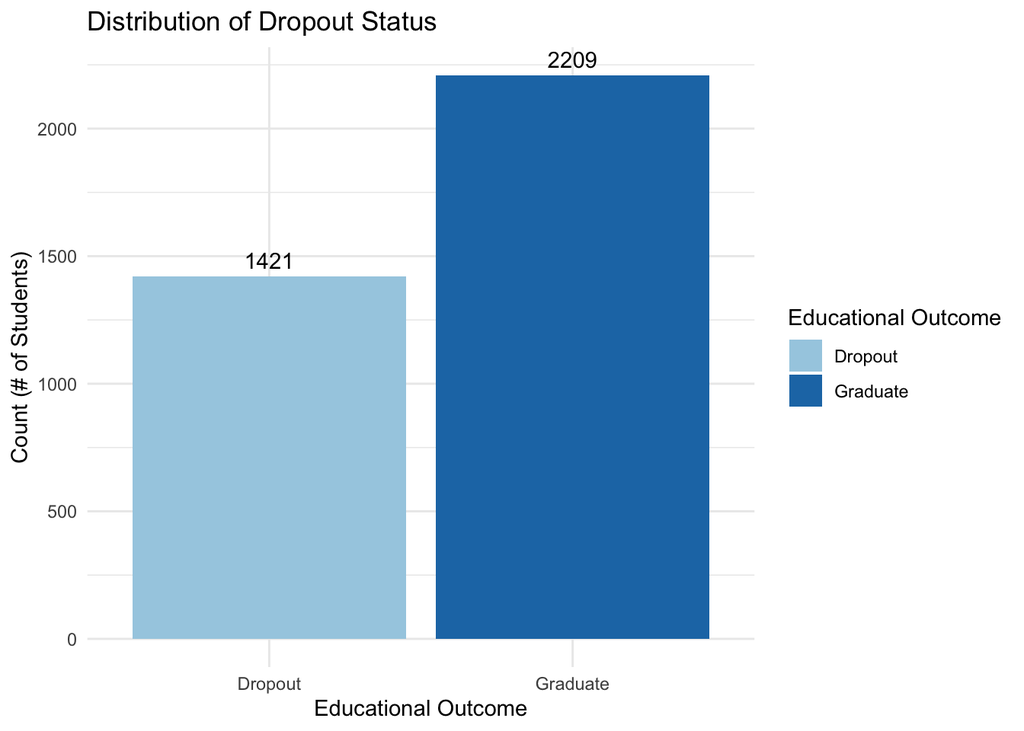

Figure 1: Distribution of Educational Outcome

This problem is classification based. The data is split on a 80-20 split, with 80 percent of the cleaned data being in the training set and 20 percent in the testing set. I used v-fold cross-validation with 5 folds and 10 repeats to estimate the performance of the models and to prevent overfitting. I will fit 12 models in total, with 6 model types being fit twice. The first recipe being used is an inclusive recipe that includes all predictor variables, and the second a feature engineered recipe with its creation being guided by the EDA. The metric I will be using to compare and select the final, best model is accuracy. This is because my data is not too imbalanced, so I want to prioritize the straightforward qualities of accuracy as my main metric.

## Finding the Best Model

Accuracy will be used as the metric to compare models and determine which one is the most successful. Table 1 contains the best performances from each model, with the best performance at the top. From this, we can see that the elastic net model that utilized the feature engineering recipe performed the best, with an extremely high accuracy of 0.91.

Table 1: Best Accuracy of All Models

| model | mean | std_err | n |
| --- | --- | --- | --- |
| Elastic Net (FE) | 0.9109447 | 0.0018806 | 50 |
| Elastic Net | 0.9090860 | 0.0017576 | 50 |
| Linear (FE) | 0.9079023 | 0.0017791 | 50 |
| Linear | 0.9076301 | 0.0020427 | 50 |
| Random Forest | 0.9037584 | 0.0028648 | 31 |
| Boosted Tree | 0.9023825 | 0.0017963 | 50 |
| Random Forest (FE) | 0.8985422 | 0.0030223 | 31 |
| Boosted Tree (FE) | 0.8978398 | 0.0020705 | 50 |
| K-nearest Neighbor (FE) | 0.8448560 | 0.0030170 | 31 |
| K-nearest Neighbor | 0.8070795 | 0.0033375 | 31 |
| Null Fit | 0.6086819 | 0.0000925 | 50 |
| Null Fit (FE) | 0.6086819 | 0.0000925 | 50 |

After fitting the best model on the resting data, the final model had an accuracy of 0.935 on the testing data, which is higher than what the training data was at 0.911. Analyzing another metric, the ROC AUC value, produces another strong result at 0.967. As the ROC AUC value is very close to 1, this suggests that the model has very high discriminatory power. This also indicates strong performance in terms of true positive and true negative rates.

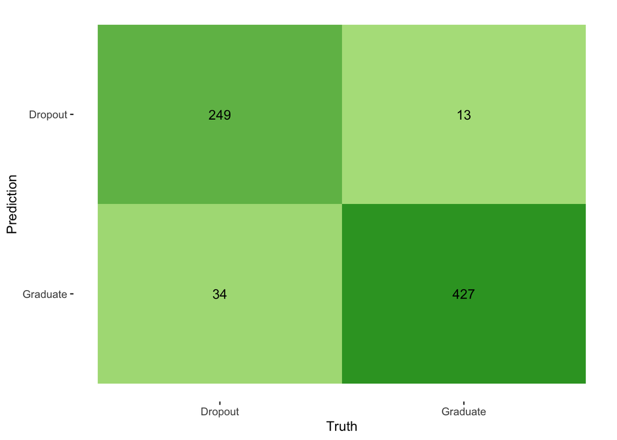

Figure 2: Confusion Matrix For Final Model Results

## Conclusion

In conclusion, the predictive model proved that it is possible to accurately predict the educational outcome of students when provided with robust enough demographic data. Knowing that predicting educational outcomes is possible is useful, considering that the experience of completing higher education can help students pursue their passions, discover new knowledge, and develop as people in general. The more students who want to access higher education and are able to finish degrees will ultimately equal more people who are able to diversify and advance society, making the world a better place for us all.

## References

Martins, M. V., Tolledo, D., Machado, J., Baptista, L. M. T., & Realinho, V. (2021). *Early Prediction of student’s Performance in Higher Education: A Case Study.* In Á. Rocha, H. Adeli, G. Dzemyda, F. Moreira, & A. M. Ramalho Correia (Eds.), Trends and Applications in Information Systems and Technologies (Vol. 1365, pp. 166–175). Springer International Publishing. https://doi.org/10.1007/978-3-030-72657-7_16

Valentim Realinho, M. V. M. (2021). *Predict students’ dropout and academic success* [dataset]. UCI Machine Learning Repository. https://doi.org/10.24432/C5MC89